# Reproducible Research: Peer Assessment 1

## Preparing the environment

The libraries that are used throughout this R Markdown file are installed if necessary and then loaded by use of the following dependency function.

```r
depend <- function (s) {
    if (s %in% rownames(installed.packages()) == FALSE) {
        install.packages(s, repos="http://cran.rstudio.com/", dependencies=TRUE)
    }
    library(s, character.only=TRUE)
}
```

## Loading and preprocessing the data

We’ll read the raw data set directly, taking care to preserve headers and format *NA* values. Date’s can be tricky when imported, so we’ll force the *date* column to be interpretted as a date.

```r
dat <- read.table(unz("activity.zip", "activity.csv"),
                  na.strings = "NA", header=T, quote="\"", sep=",")
dat$date <- as.Date(dat$date)
```

Inspecting the data shows well formated column names as well as good data for the *date* and *interval* columns.

```r
head(dat)
```

```
##   steps       date interval
## 1    NA 2012-10-01        0
## 2    NA 2012-10-01        5
## 3    NA 2012-10-01       10
## 4    NA 2012-10-01       15
## 5    NA 2012-10-01       20
## 6    NA 2012-10-01       25
```

A quick sum shows that there is good data further down in the *steps* column as well.

```r
sum(dat$steps,na.rm=TRUE)
```

```
## [1] 570608
```

## What is mean total number of steps taken per day?

### Libraries

We’ll be using the *ggplot2* library for all plots. The *scales* library helps us with breaks and graph limiting, and *ggthemes* brings us a wonderful collection of colors.

Tidying the data will be done by with the *dplyr* library and *magrittr* piping.

```r
depend("ggplot2")
depend("scales")
depend("ggthemes")
depend("dplyr")
```

### Steps per day

To calculate the number of steps per day, we group all of our data by each day and take the sum of each group. The result table can be used to draw a plot for each day.

```r
steps_per_day <- dat %>%
    select(steps, date) %>%
    group_by(date) %>%
    summarize(steps=sum(steps))
```

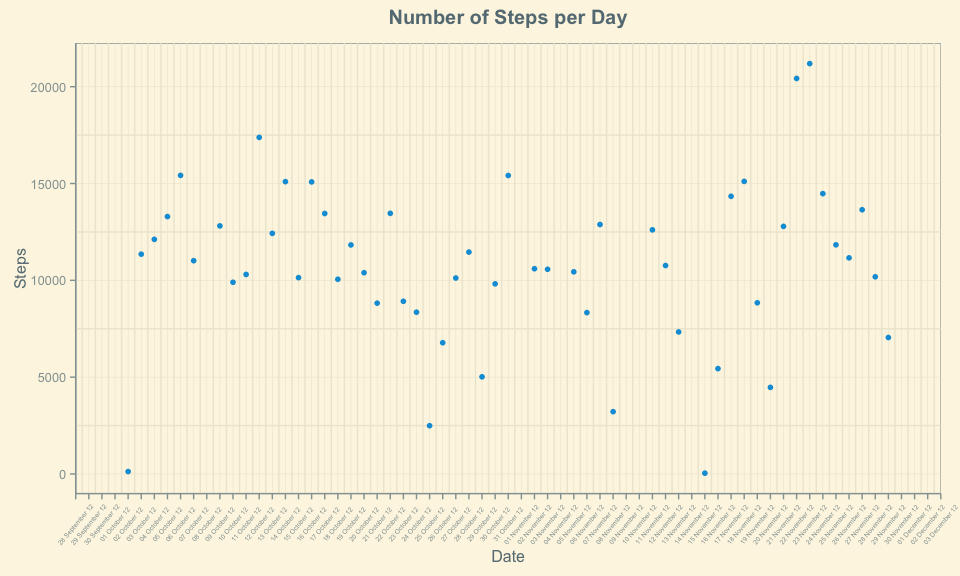

```r
ggplot(steps_per_day, aes(date,steps), na.rm = TRUE) +
    geom_point(size=2, color="#099DD9") +
    theme_solarized() +
    scale_colour_solarized("red") +
    labs(x="Date", y="Steps", title="Number of Steps per Day") +
    theme(plot.title=element_text(size=15, face="bold", vjust=2)) +
    theme(legend.title=element_blank()) +
    theme(axis.text.x=element_text(angle=50, size=5, vjust=0.5)) +
    scale_x_date(breaks = "1 day", labels=date_format("%d %B %y"))
```

### Histogram of steps per day

In addition to the literal number of steps per day, we can also look at a histogram of step intervals to identify the shape of the data and the likelihood of outliers.

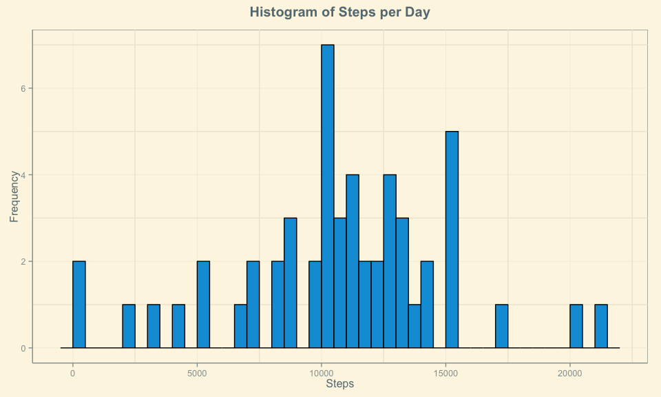

```r
ggplot(steps_per_day, aes(steps)) +
    geom_histogram(binwidth=500, color = "black", fill = "#099DD9") +
    theme_solarized() +
    labs(x="Steps", y="Frequency", title="Histogram of Steps per Day") +
    theme(plot.title=element_text(size=15, face="bold", vjust=2)) +
    theme(legend.title=element_blank())
```

### Mean and Median

With the *steps_per_day* table, calculating the mean and median values per day is a straight forward operation.

```r
mean(steps_per_day$steps, na.rm=TRUE)
```

```
## [1] 10766
```

```r
median(steps_per_day$steps, na.rm=TRUE)
```

```
## [1] 10765
```

## What is the average daily activity pattern?

### Libraries

To better access date-time information from the tables, we will use the *lubridate* library. To facilitate the tidy step, *stringr* will give the ability to pad a numeric string, helpful in the time transformation below.

```r
depend("lubridate")
depend("stringr")
```

### Time Series

The *interval* column is really nothing more than a badly formatted time column. By grouping by that column and taking the average of the steps, we can plot a time series.

```r
time_series <- dat %>%
    mutate(interval=parse_date_time(str_pad(interval, 4, pad="0"), "%H%M")) %>%
    group_by(interval) %>%
    summarize(steps=mean(steps, na.rm=TRUE))
head(time_series)
```

```
## Source: local data frame [6 x 2]
##
##              interval   steps
## 1 0000-01-01 00:00:00 1.71698
## 2 0000-01-01 00:05:00 0.33962
## 3 0000-01-01 00:10:00 0.13208
## 4 0000-01-01 00:15:00 0.15094
## 5 0000-01-01 00:20:00 0.07547
## 6 0000-01-01 00:25:00 2.09434
```

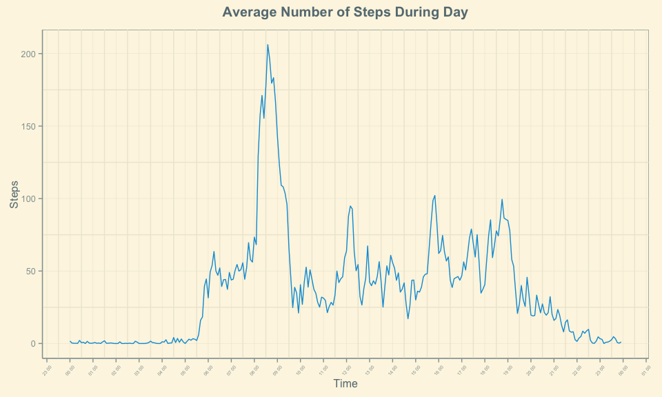

```r
ggplot(time_series, aes(interval,steps)) +
    geom_line(color="#099DD9") +
    theme_solarized() +
    scale_colour_solarized("red") +
    labs(x="Time", y="Steps", title="Average Number of Steps During Day") +
    theme(plot.title=element_text(size=15, face="bold", vjust=2)) +
    theme(legend.title=element_blank()) +
    theme(axis.text.x=element_text(angle=50, size=5, vjust=0.5)) +
    scale_x_datetime(breaks = "60 min", labels=date_format("%H %M"))
```

### Highest average 5-minute interval

Looking at the graph, it is easy to estimate the highest peak falling slightly after 8:30am. We can get a more accurate picture by looking for the row with the maximum step value, then formatting the time interval to be human readible.

```r
max_row <- time_series[which.max(time_series$steps),]
max_interval <- max_row$interval
paste(hour(max_interval),minute(max_interval),sep=":")
```

```
## [1] "8:35"
```

8:35am matches the graph expectations.

## Imputing missing values

### How many NA values

A number of the rows in this data set contain missing values. Looking row-wise at the entire data set, we can count how many have *NA* values and how many do not.

```r
na_dat <- dat[!complete.cases(dat),]
complete_dat <- dat[complete.cases(dat),]
nrow(na_dat)
```

```
## [1] 2304
```

```r
nrow(complete_dat)
```

```
## [1] 15264
```

### Filling in the gaps

We can attempt to infer the values of the NA positions by leveraging the mean step count for that 5-minute interval and inserting that value in place of the NA.

- First we will format the interval column to match the datetime format used in our lookup table, *time_series*.
- We identify which rows contain missing *steps* information.
- We identify the *interval* value for each of these rows.
- We use this *interval* value to look up the replacement *steps* value from *time_series*.

```r
dat_fill <- dat %>%
    mutate(interval=parse_date_time(str_pad(interval, 4, pad="0"), "%H%M"))

na.steps <- which(is.na(dat_fill$steps))
na.interval <- dat_fill$interval[na.steps]
dat_fill$steps[na.steps] <- time_series$steps[match(na.interval, time_series$interval)]

head(dat_fill)
```

```
##     steps       date            interval
## 1 1.71698 2012-10-01 0000-01-01 00:00:00
## 2 0.33962 2012-10-01 0000-01-01 00:05:00
## 3 0.13208 2012-10-01 0000-01-01 00:10:00
## 4 0.15094 2012-10-01 0000-01-01 00:15:00
## 5 0.07547 2012-10-01 0000-01-01 00:20:00
## 6 2.09434 2012-10-01 0000-01-01 00:25:00
```

### Histogram of changes

```r
steps_per_day_fill <- dat_fill %>%
    select(steps, date) %>%
    group_by(date) %>%
    summarize(steps=sum(steps))
```

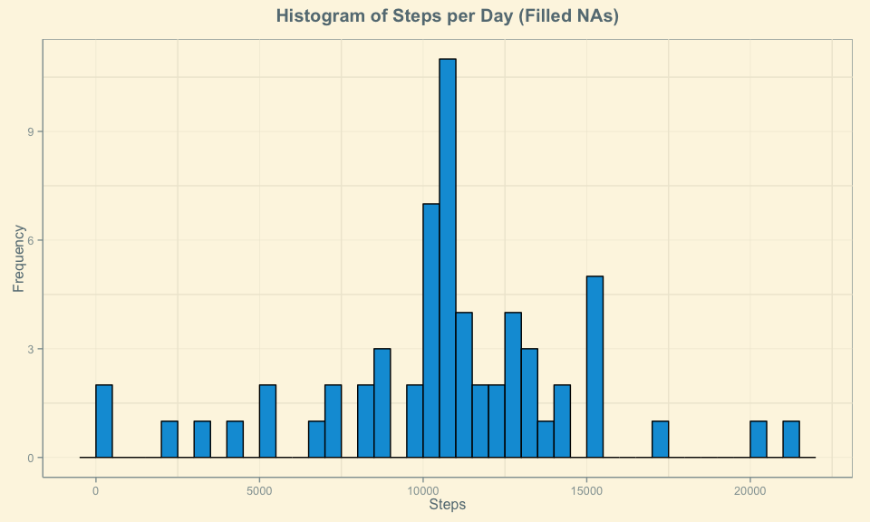

```r
ggplot(steps_per_day_fill, aes(steps)) +
    geom_histogram(binwidth=500, color = "black", fill = "#099DD9") +
    theme_solarized() +
    labs(x="Steps", y="Frequency", title="Histogram of Steps per Day (Filled NAs)") +
    theme(plot.title=element_text(size=15, face="bold", vjust=2)) +
    theme(legend.title=element_blank())
```

### Mean and Median

In calculating the mean & median values of the *steps_per_day_fill* table, there is a small change in the median, but no visible change in the mean. This suggests that the missing NA values were evenly distrubuted so that by filling them we have not shifted anything.

```r
mean(steps_per_day_fill$steps)
```

```
## [1] 10766
```

```r
median(steps_per_day_fill$steps)
```

```
## [1] 10766
```

Looking at the total number of steps from the original data table versus our filled data table reveals just how many new steps have been interpolated.

```r
total_steps <- sum(dat$steps,na.rm=TRUE)
total_steps
```

```
## [1] 570608
```

```r
total_steps_fill <- sum(dat_fill$steps)
total_steps_fill
```

```
## [1] 656738
```

```r
total_steps_fill - total_steps
```

```
## [1] 86130
```

## Are there differences in activity patterns between weekdays and weekends?

We create a new factor variable in the dataset, *week*, with two levels – “weekday” and “weekend” indicating whether a given date is a weekday or weekend day.

```r
dat_fill <- dat_fill %>%
    mutate ( week = ifelse( wday(date, label = TRUE, abbr = FALSE) %in%
                           c("Saturday", "Sunday"), "weekend", "weekday"))

head(dat_fill)
```

```
##     steps       date            interval    week
## 1 1.71698 2012-10-01 0000-01-01 00:00:00 weekday
## 2 0.33962 2012-10-01 0000-01-01 00:05:00 weekday
## 3 0.13208 2012-10-01 0000-01-01 00:10:00 weekday
## 4 0.15094 2012-10-01 0000-01-01 00:15:00 weekday
## 5 0.07547 2012-10-01 0000-01-01 00:20:00 weekday
## 6 2.09434 2012-10-01 0000-01-01 00:25:00 weekday
```

Finally, we can plot a time series of our filled data set, breaking the weekday or weekend factors by color. Overlaying the plots shows the obvious differences in steps throughout the day for a weekend vs weekday.

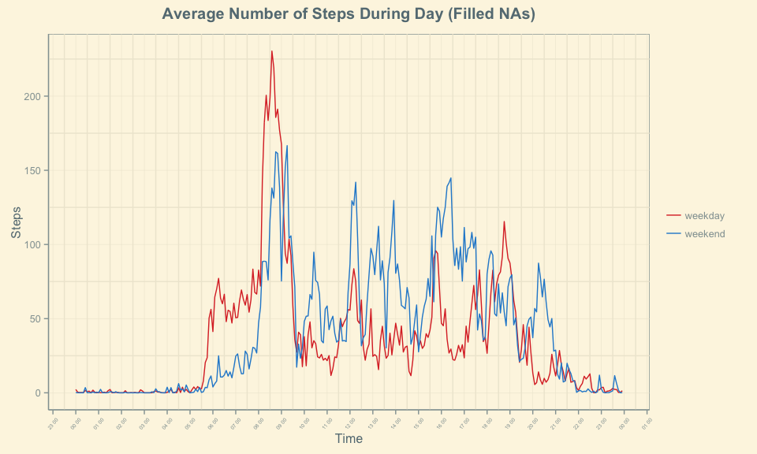

```r
time_series_fill <- dat_fill %>%
    group_by(interval, week) %>%
    summarize(steps=mean(steps, na.rm=TRUE))

ggplot(time_series_fill, aes(interval, steps, col=week) ) +
    geom_line( ) +
    theme_solarized() +
    scale_colour_solarized("red") +
    labs(x="Time", y="Steps", title="Average Number of Steps During Day (Filled NAs)") +
    theme(plot.title=element_text(size=15, face="bold", vjust=2)) +
    theme(legend.title=element_blank()) +
    theme(axis.text.x=element_text(angle=50, size=5, vjust=0.5)) +
    scale_x_datetime(breaks = "60 min", labels=date_format("%H %M"))
```